# KurczFinalProject

## MSDS 430 Final Project

### December 8, 2019

The following notebook analyzes the behavior of U.S. Wildfires between 1992 and 2015.

1. The data is a sqlite file so there's some cleaning up there.
2. Then there is some exploratory analysis using pandas, numpy, seaborn, and matplotlib.
3. I will also attempt to regionalize the fires and then predict whether one region can predict fires in another region the following year.
4. Finally, the conclusions. Where are fires most prevalent? Can fires in one year in one region predict those in another region the next year? Is there some pattern country-wide?

## U.S. Wildfires

Source: https://www.kaggle.com/rtatman/188-million-us-wildfires/download#FPA_FOD_20170508.sqlite

Source info: https://www.kaggle.com/rtatman/188-million-us-wildfires/

Dates: 1992 - 2015

Region Source: https://www.worldatlas.com/articles/the-regions-of-the-united-states.html

```python
import pandas
import numpy as np
import matplotlib.pyplot as plt
import sqlite3
import seaborn as sns
import pandas_profiling
import stats
conn = sqlite3.connect("../data/FPA_FOD_20170508.sqlite")
cur = conn.cursor()

plt.figure.max_open_warning = False
```

## Getting to understand the data

While Kaggle's documentation goes into detail about what's inside the SQLite file, I like to see for myself what tables are inside the instance I have in my memory, just to confirm they match. They do.

```python
cur.execute("SELECT name FROM sqlite_master WHERE type='table';")
output = cur.fetchall()
tables = [table[0] for table in output]
tables.sort() # sorting alphabetically for readability
print(tables)
```

```
['ElementaryGeometries', 'Fires', 'KNN', 'NWCG_UnitIDActive_20170109', 'SpatialIndex', 'geometry_columns', 'geometry_columns_auth', 'geometry_columns_field_infos', 'geometry_columns_statistics', 'geometry_columns_time', 'idx_Fires_Shape', 'idx_Fires_Shape_node', 'idx_Fires_Shape_parent', 'idx_Fires_…
```

This project will focus only on the Fires table.

## Getting column information from sqlite file itself, to later compare to pandas datafrae

```python
query = cur.execute("SELECT * FROM fires;")
# this will point cur.description to the table fires

names = [description[0] for description in cur.description]
num_cols_fires = len(names)
# this I will not sort because the order should coordinate with data

print(names, "\n\n--> column count sqlite file : ", num_cols_fires)
```

```
['OBJECTID', 'FOD_ID', 'FPA_ID', 'SOURCE_SYSTEM_TYPE', 'SOURCE_SYSTEM', 'NWCG_REPORTING_AGENCY', 'NWCG_REPORTING_UNIT_ID', 'NWCG_REPORTING_UNIT_NAME', 'SOURCE_REPORTING_UNIT', 'SOURCE_REPORTING_UNIT_NAME', 'LOCAL_FIRE_REPORT_ID', 'LOCAL_INCIDENT_ID', 'FIRE_CODE', 'FIRE_NAME', 'ICS_209_INCIDENT_NUMBE…

--> column count sqlite file :  39
```

## SQLite Rowcount

Before converting into pandas Dataframe, want to know the number of rows in SQLite file to assert conversion was successful.

```python
cur.execute("SELECT COUNT(*) FROM fires;")
num_rows_fires = cur.fetchone()[0]
print("row count sqlite file : ", num_rows_fires)
# later we will confirm this is the same as in the dataframe
```

```
row count sqlite file :  1880465
```

```python
sqlite_dim = (num_rows_fires, num_cols_fires)
# storing sqlite dimension information for convenience
```

## Creating the dataframe from SQLite file

According to Kaggle's documentation, FOD_ID is the global unique identifier. This will become the pandas index column.

```python
# the step which stores fires table in pandas dataframe, df (takes a few minutes due to large file size)
df = pandas.read_sql("SELECT * FROM fires;", conn, index_col="FOD_ID")
```

```python
# verifying the length of the dataframe loaded is the same as that in the actual table, sqllite file
len(df) == num_rows_fires
```

```
True
```

Number of rows in both elements the same. I will now proceed further.

# First 5 elements

```python
df.head(5)
# first 5 elements
```

| FOD_ID | OBJECTID | FPA_ID | SOURCE_SYSTEM_TYPE | SOURCE_SYSTEM | NWCG_REPORTING_AGENCY | NWCG_REPORTING_UNIT_ID | NWCG_REPORTING_UNIT_NAME | SOURCE_REPORTING_UNIT | SOURCE_REPORTING_UNIT_NAME | LOCAL_FIRE_REPORT_ID | ... | FIRE_SIZE_CLASS | LATITUDE | LONGITUDE | OWNER_CODE | OWNER_DESCR | STATE | COUNTY | FIPS_CODE | FIPS_NAME | Shape |
| --- | --- | --- | --- | --- | --- | --- | --- | --- | --- | --- | --- | --- | --- | --- | --- | --- | --- | --- | --- | --- | --- |
| 1 | 1 | FS-1418826 | FED | FS-FIRESTAT | FS | USCAPNF | Plumas National Forest | 0511 | Plumas National Forest | 1 | ... | A | 40.036944 | -121.005833 | 5.0 | USFS | CA | 63 | 063 | Plumas | b'\x00\x01\xad\x10\x00\x00\xe8d\xc2\x92_@^\xc0... |
| 2 | 2 | FS-1418827 | FED | FS-FIRESTAT | FS | USCAENF | Eldorado National Forest | 0503 | Eldorado National Forest | 13 | ... | A | 38.933056 | -120.404444 | 5.0 | USFS | CA | 61 | 061 | Placer | b'\x00\x01\xad\x10\x00\x00T\xb6\xeej\xe2\x19^\... |
| 3 | 3 | FS-1418835 | FED | FS-FIRESTAT | FS | USCAENF | Eldorado National Forest | 0503 | Eldorado National Forest | 27 | ... | A | 38.984167 | -120.735556 | 13.0 | STATE OR PRIVATE | CA | 17 | 017 | El Dorado | b'\x00\x01\xad\x10\x00\x00\xd0\xa5\xa0W\x13/^\... |
| 4 | 4 | FS-1418845 | FED | FS-FIRESTAT | FS | USCAENF | Eldorado National Forest | 0503 | Eldorado National Forest | 43 | ... | A | 38.559167 | -119.913333 | 5.0 | USFS | CA | 3 | 003 | Alpine | b'\x00\x01\xad\x10\x00\x00\x94\xac\xa3\rt\xfa]... |
| 5 | 5 | FS-1418847 | FED | FS-FIRESTAT | FS | USCAENF | Eldorado National Forest | 0503 | Eldorado National Forest | 44 | ... | A | 38.559167 | -119.933056 | 5.0 | USFS | CA | 3 | 003 | Alpine | b'\x00\x01\xad\x10\x00\x00@\xe3\xaa.\xb7\xfb]\... |

5 rows × 38 columns

# Last 5 elements

```python
df.tail(5)

# last 5 elements
```

| FOD_ID | OBJECTID | FPA_ID | SOURCE_SYSTEM_TYPE | SOURCE_SYSTEM | NWCG_REPORTING_AGENCY | NWCG_REPORTING_UNIT_ID | NWCG_REPORTING_UNIT_NAME | SOURCE_REPORTING_UNIT | SOURCE_REPORTING_UNIT_NAME | LOCAL_FIRE_REPORT_ID | ... | FIRE_SIZE_CLASS | LATITUDE | LONGITUDE | OWNER_CODE | OWNER_DESCR | STATE | COUNTY | FIPS_CODE | FIPS_NAME | Shape |
| --- | --- | --- | --- | --- | --- | --- | --- | --- | --- | --- | --- | --- | --- | --- | --- | --- | --- | --- | --- | --- | --- |
| 300348363 | 1880461 | 2015CAIRS29019636 | NONFED | ST-CACDF | ST/C&L | USCASHU | Shasta-Trinity Unit | CASHU | Shasta-Trinity Unit | 591814 | ... | A | 40.481637 | -122.389375 | 13.0 | STATE OR PRIVATE | CA | None | None | None | b'\x00\x01\xad\x10\x00\x00P\xb8\x1e\x85\xeb\x9... |
| 300348373 | 1880462 | 2015CAIRS29217935 | NONFED | ST-CACDF | ST/C&L | USCATCU | Tuolumne-Calaveras Unit | CATCU | Tuolumne-Calaveras Unit | 569419 | ... | A | 37.617619 | -120.938570 | 12.0 | MUNICIPAL/LOCAL | CA | None | None | None | b'\x00\x01\xad\x10\x00\x00\x00\x80\xbe\x88\x11... |
| 300348375 | 1880463 | 2015CAIRS28364460 | NONFED | ST-CACDF | ST/C&L | USCATCU | Tuolumne-Calaveras Unit | CATCU | Tuolumne-Calaveras Unit | 574245 | ... | A | 37.617619 | -120.938570 | 12.0 | MUNICIPAL/LOCAL | CA | None | None | None | b'\x00\x01\xad\x10\x00\x00\x00\x80\xbe\x88\x11... |
| 300348377 | 1880464 | 2015CAIRS29218079 | NONFED | ST-CACDF | ST/C&L | USCATCU | Tuolumne-Calaveras Unit | CATCU | Tuolumne-Calaveras Unit | 570462 | ... | B | 37.672235 | -120.898356 | 12.0 | MUNICIPAL/LOCAL | CA | None | None | None | b'\x00\x01\xad\x10\x00\x00x\xba_\xaa~9^\xc0\xb... |
| 300348399 | 1880465 | 2015CAIRS26733926 | NONFED | ST-CACDF | ST/C&L | USCABDU | San Bernardino Unit | CABDU | CDF - San Bernardino Unit | 535436 | ... | A | 34.263217 | -116.830950 | 13.0 | STATE OR PRIVATE | CA | None | None | None | b'\x00\x01\xad\x10\x00\x00\x1c\xa7\xe8H.5]\xc0... |

5 rows × 38 columns

```python
# Extracting CA info

CA = df[df['STATE']=='CA']
CA.head()
```

| FOD_ID | OBJECTID | FPA_ID | SOURCE_SYSTEM_TYPE | SOURCE_SYSTEM | NWCG_REPORTING_AGENCY | NWCG_REPORTING_UNIT_ID | NWCG_REPORTING_UNIT_NAME | SOURCE_REPORTING_UNIT | SOURCE_REPORTING_UNIT_NAME | LOCAL_FIRE_REPORT_ID | ... | FIRE_SIZE_CLASS | LATITUDE | LONGITUDE | OWNER_CODE | OWNER_DESCR | STATE | COUNTY | FIPS_CODE | FIPS_NAME | Shape |
| --- | --- | --- | --- | --- | --- | --- | --- | --- | --- | --- | --- | --- | --- | --- | --- | --- | --- | --- | --- | --- | --- |
| 1 | 1 | FS-1418826 | FED | FS-FIRESTAT | FS | USCAPNF | Plumas National Forest | 0511 | Plumas National Forest | 1 | ... | A | 40.036944 | -121.005833 | 5.0 | USFS | CA | 63 | 063 | Plumas | b'\x00\x01\xad\x10\x00\x00\xe8d\xc2\x92_@^\xc0... |
| 2 | 2 | FS-1418827 | FED | FS-FIRESTAT | FS | USCAENF | Eldorado National Forest | 0503 | Eldorado National Forest | 13 | ... | A | 38.933056 | -120.404444 | 5.0 | USFS | CA | 61 | 061 | Placer | b'\x00\x01\xad\x10\x00\x00T\xb6\xeej\xe2\x19^\... |
| 3 | 3 | FS-1418835 | FED | FS-FIRESTAT | FS | USCAENF | Eldorado National Forest | 0503 | Eldorado National Forest | 27 | ... | A | 38.984167 | -120.735556 | 13.0 | STATE OR PRIVATE | CA | 17 | 017 | El Dorado | b'\x00\x01\xad\x10\x00\x00\xd0\xa5\xa0W\x13/^\... |
| 4 | 4 | FS-1418845 | FED | FS-FIRESTAT | FS | USCAENF | Eldorado National Forest | 0503 | Eldorado National Forest | 43 | ... | A | 38.559167 | -119.913333 | 5.0 | USFS | CA | 3 | 003 | Alpine | b'\x00\x01\xad\x10\x00\x00\x94\xac\xa3\rt\xfa]... |
| 5 | 5 | FS-1418847 | FED | FS-FIRESTAT | FS | USCAENF | Eldorado National Forest | 0503 | Eldorado National Forest | 44 | ... | A | 38.559167 | -119.933056 | 5.0 | USFS | CA | 3 | 003 | Alpine | b'\x00\x01\xad\x10\x00\x00@\xe3\xaa.\xb7\xfb]\... |

5 rows × 38 columns

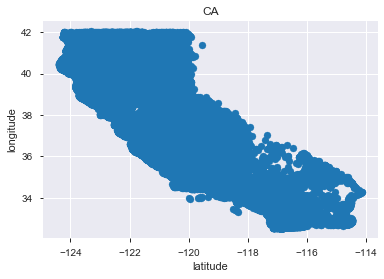

```python
plt.scatter(CA["LONGITUDE"], CA["LATITUDE"])
plt.xlabel("latitude")
plt.ylabel("longitude")
plt.title("CA")
plt.savefig("CA.png")

# just thought it would be cool to plot California with Fire coordinates
```

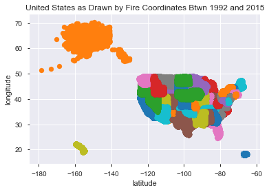

```python
# going a step further to plot all the lat, long coordintes in the dataset

states = df["STATE"].unique()

for state in states:
    st = df[df["STATE"]==state]
    plt.scatter(st["LONGITUDE"], st["LATITUDE"])

plt.xlabel("latitude")
plt.ylabel("longitude")
plt.title("United States as Drawn by Fire Coordinates Btwn 1992 and 2015")
plt.savefig("united_states_kid_drawing.png".format(state))
```

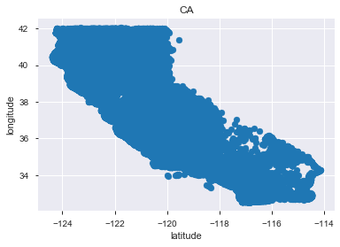

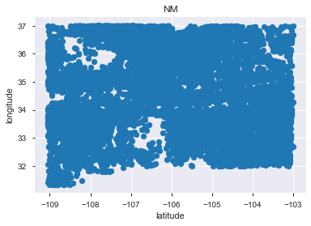

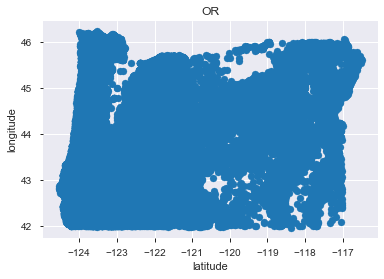

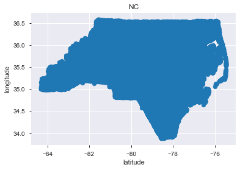

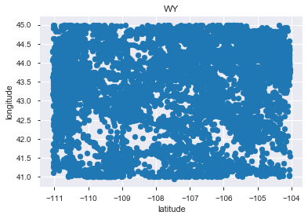

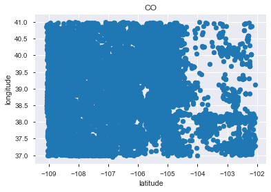

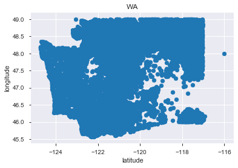

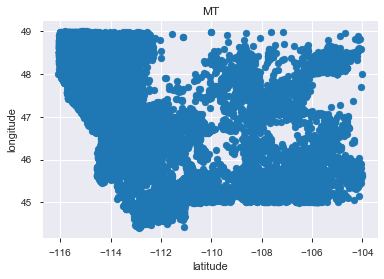

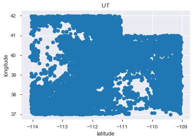

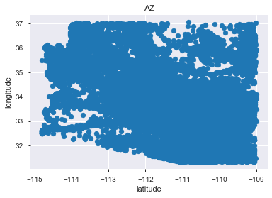

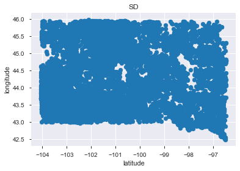

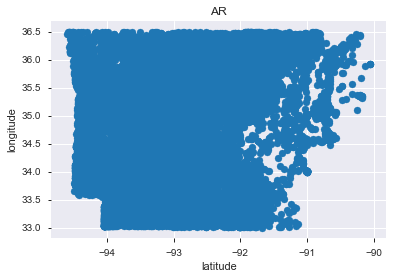

[40 more figures not shown]

```python
# plotting states individually

for state in states:
    st = df[df["STATE"]==state]
    plt.figure()
    plt.xlabel("latitude")
    plt.ylabel("longitude")
    plt.title(state)
    plt.scatter(st["LONGITUDE"], st["LATITUDE"])
    if state == "ND" or state == "NY" or state == "RI" or state == "NC":
        plt.savefig("{}.png".format(state))
```

```python
# going a step further from head() by taking a look at the unique values of each attribute
unique_things = {}

for column in df.columns:
    unique_things[column] = df[column].unique()
```

```python
# printing unique_things in a somewhat human-friendly way
for key, val in unique_things.items():
    print("key: {}\nval:{}\n".format(key, val))
```

```
key: OBJECTID
val:[      1       2       3 ... 1880463 1880464 1880465]

key: FPA_ID
val:['FS-1418826' 'FS-1418827' 'FS-1418835' ... '2015CAIRS28364460'
 '2015CAIRS29218079' '2015CAIRS26733926']

key: SOURCE_SYSTEM_TYPE
val:['FED' 'NONFED' 'INTERAGCY']

key: SOURCE_SYSTEM
val:['FS-FIRESTAT' 'DOI-WFMI' 'FWS-FMIS' 'FA-NFIRS' 'ST-NASF' 'ST-AZAZS'
 'ST-MOMOS' 'IA-AKACC' 'ST-MTMTS' 'ST-SCSCS' 'ST-COCOS' 'ST-MEMES'
 'ST-ORORS' 'ST-MSMSS' 'ST-NMNMS' 'ST-SDSDS' 'ST-UTUTS' 'ST-WAWAS'
 'ST-WYWYS' 'ST-OKOKS' 'ST-WIWIS' 'ST-MIMIS' 'ST-KYKYS' 'ST-ALALS'
 'ST-ARARS' 'ST-GAGAS' 'ST-LALAS' 'ST-TNTNS' 'ST-VAVAS' 'ST-FLFLS'
 'ST-NCNCS' 'IA-ICS209' 'ST-CACDF' 'ST-CTCTS' 'ST-NENES' 'ST-TXTXS'
 'IA-PRIITF' 'IA-HIWMO']

key: NWCG_REPORTING_AGENCY
val:['FS' 'BIA' 'TRIBE' 'BLM' 'NPS' 'BOR' 'FWS' 'ST/C&L' 'DOD' 'IA' 'DOE']

key: NWCG_REPORTING_UNIT_ID
val:['USCAPNF' 'USCAENF' 'USCASHF' ... 'USPRPRS' 'USWYPLX' 'USHINPS']

key: NWCG_REPORTING_UNIT_NAME
val:['Plumas National Forest' 'Eldorado National Forest'
 'Shasta-Trinity National Forest' ... 'Puerto Rico Fire Service'
 'Platte County' 'National Parks in Hawaii']

key: SOURCE_REPORTING_UNIT
val:['0511' '0503' '0514' ... 'WYPLX' 'COH-HFD' 'HINPS']

key: SOURCE_REPORTING_UNIT_NAME
val:['Plumas National Forest' 'Eldorado National Forest'
 'Shasta-Trinity National Forest' ...
 'County of Hawaii - Hawaii Fire Department' 'Honolulu Fire Dept'
 'National Parks in Hawaii']

key: LOCAL_FIRE_REPORT_ID
```

[output cut: 158 more lines]

```
 '341' '421' '433' '501' '445' '431' '399' '489' '389' '495' '357' '323'
 '40' '481' '036' '570' '800' '810' '550' '650' '700' '530' '730' '078'
 '186' '086' '461' '290' '240' '760' '150' '050' '188' '270']

key: FIPS_NAME
val:['Plumas' 'Placer' 'El Dorado' ... "O'Brien" 'Gurabo Municipio' 'Garvin']

key: Shape
val:[b'\x00\x01\xad\x10\x00\x00\xe8d\xc2\x92_@^\xc0\xe0\xc8l\x98\xba\x04D@\xe8d\xc2\x92_@^\xc0\xe0\xc8l\x98\xba\x04D@|\x01\x00\x00\x00\xe8d\xc2\x92_@^\xc0\xe0\xc8l\x98\xba\x04D@\xfe'
 b'\x00\x01\xad\x10\x00\x00T\xb6\xeej\xe2\x19^\xc0\x90\xc6U]nwC@T\xb6\xeej\xe2\x19^\xc0\x90\xc6U]nwC@|\x01\x00\x00\x00T\xb6\xeej\xe2\x19^\xc0\x90\xc6U]nwC@\xfe'
 b'\x00\x01\xad\x10\x00\x00\xd0\xa5\xa0W\x13/^\xc0P\xbbf,\xf9}C@\xd0\xa5\xa0W\x13/^\xc0P\xbbf,\xf9}C@|\x01\x00\x00\x00\xd0\xa5\xa0W\x13/^\xc0P\xbbf,\xf9}C@\xfe'
 ...
 b'\x00\x01\xad\x10\x00\x00P\xb8\x1e\x85\xeb\x98^\xc0\x98\xc5\xfdG\xa6=D@P\xb8\x1e\x85\xeb\x98^\xc0\x98\xc5\xfdG\xa6=D@|\x01\x00\x00\x00P\xb8\x1e\x85\xeb\x98^\xc0\x98\xc5\xfdG\xa6=D@\xfe'
 b'\x00\x01\xad\x10\x00\x00x\xba_\xaa~9^\xc0\xb8dL\xc9\x0b\xd6B@x\xba_\xaa~9^\xc0\xb8dL\xc9\x0b\xd6B@|\x01\x00\x00\x00x\xba_\xaa~9^\xc0\xb8dL\xc9\x0b\xd6B@\xfe'
 b'\x00\x01\xad\x10\x00\x00\x1c\xa7\xe8H.5]\xc00`;\x18\xb1!A@\x1c\xa7\xe8H.5]\xc00`;\x18\xb1!A@|\x01\x00\x00\x00\x1c\xa7\xe8H.5]\xc00`;\x18\xb1!A@\xfe']
```